# Elementary Algebraic Structures

Analysis of complex networks with algebra* Sunbelt 2022 Conference – Workshop 39 (part 2)

Antonio Rivero Ostoic

Sch Culture & Soc, Aarhus University

jaro@cas.au.dk

4 July 2022

## Elementary structures

An example of an elementary structure is found in *Dihedral group*.

## Dihedral group of the Equilateral Triangle

The Dihedral group of the Equilateral Triangle, denoted as $D_3$, is an example of group structure. In order to construct it, we start by finding all possible combinations of three elements, and follow the process.

```r
# all combinations of three variables
pm <- expand.grid(rep(list(seq_len(3)),3))
```

```
   Var1 Var2 Var3
1     1    1    1
2     2    1    1
3     3    1    1
4     1    2    1
5     2    2    1
6     3    2    1
7     1    3    1
8     2    3    1
9     3    3    1
10    1    1    2
11    2    1    2
12    3    1    2
13    1    2    2
14    2    2    2
15    3    2    2
16    1    3    2
17    2    3    2
18    3    3    2
19    1    1    3
20    2    1    3
21    3    1    3
22    1    2    3
23    2    2    3
24    3    2    3
25    1    3    3
26    2    3    3
27    3    3    3
```

```r
#  data frame for the unique combinations in 'pm'
pmd <- data.frame(matrix(NA, ncol=3, nrow=0))
for(i in rev(seq_len(nrow(pm)))) {
    pmv <- as.vector(unlist(pm[i,]))
# make sure that each element appears just once
    if(isTRUE(sum(pmv)==6L)==TRUE && length(unique(pmv))==ncol(pm)) {
       pmd[nrow(pmd)+1L,] <- as.vector(pm[i,]) }
    }
```

`pmd` records the combinations for the construction of the dihedral group $D_3$.

```r
pmd
```

```
   X1 X2 X3
22  1  2  3
20  2  1  3
16  1  3  2
12  3  1  2
8   2  3  1
6   3  2  1
```

### Plotting

```r
# object 'tri' represents the equilateral triangle
tri <- transf(c("1, 2", "1, 3", "2, 3"))
```

```
  1 2 3
1 0 1 1
2 0 0 1
3 0 0 0
```

```r
# define scope of node / edge / graph characteristics
scpt <- list(directed=FALSE, cex=10, lwd=10, ecol=1, pos=0, cex.main=3)
```

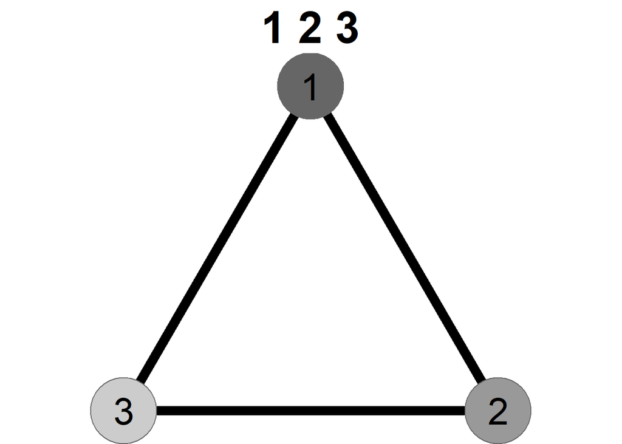

$R_0$

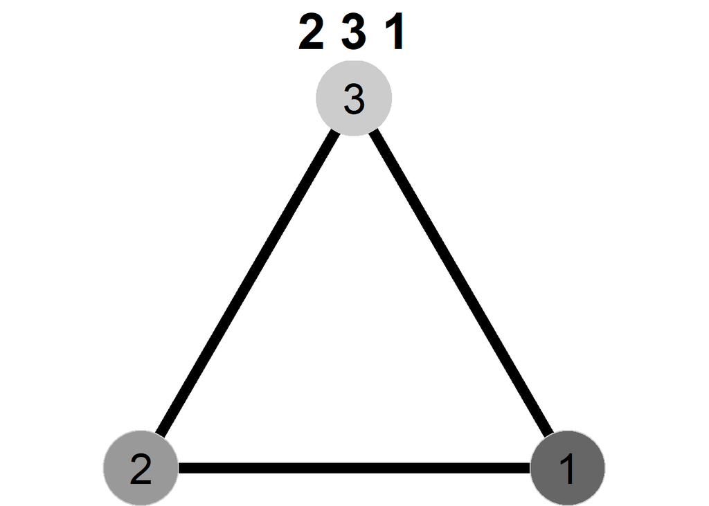

$R_{120}$

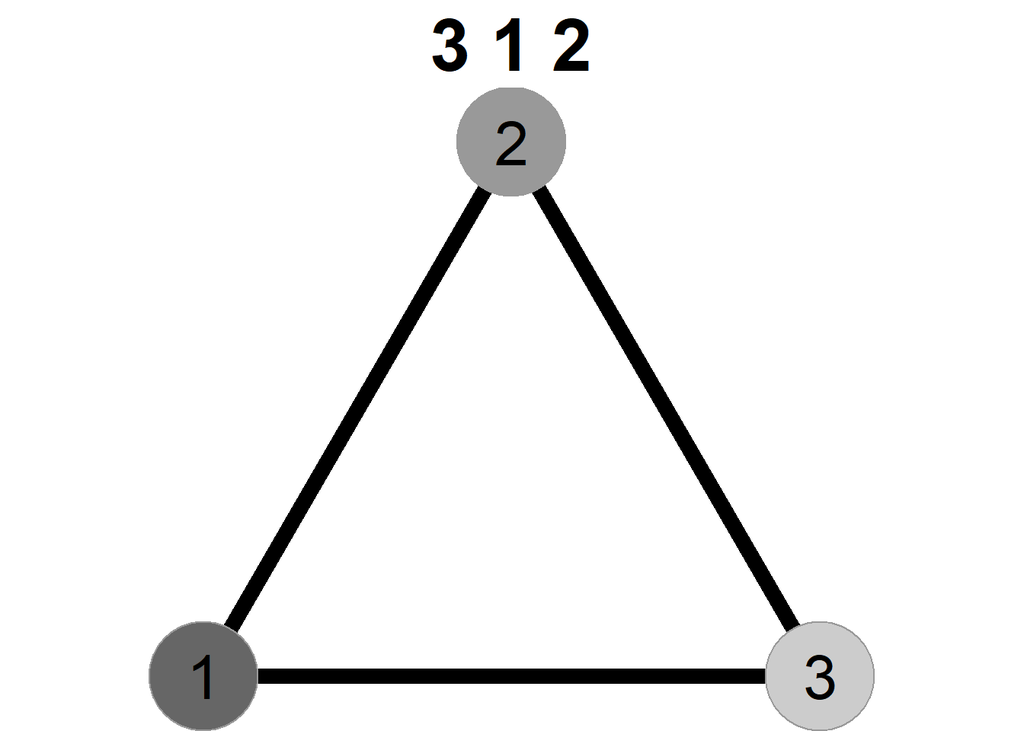

$R_{240}$

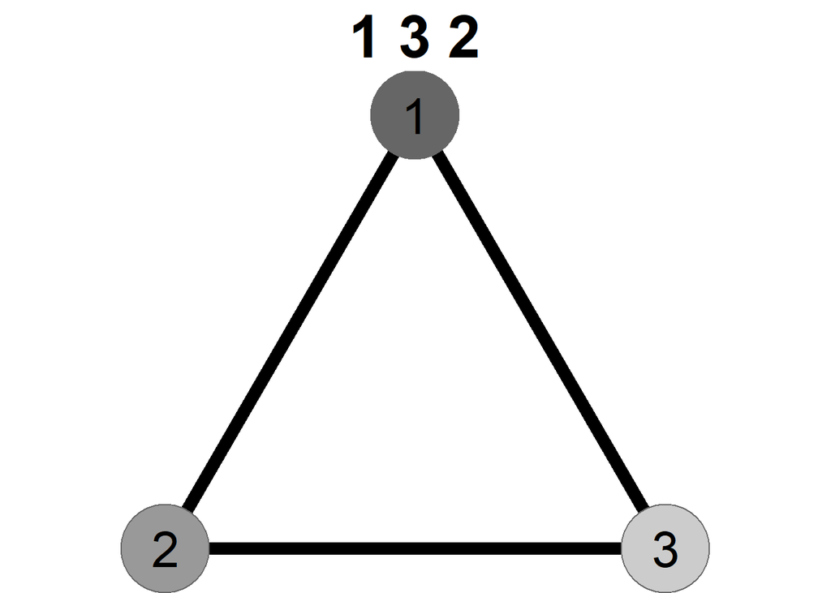

$S_V$

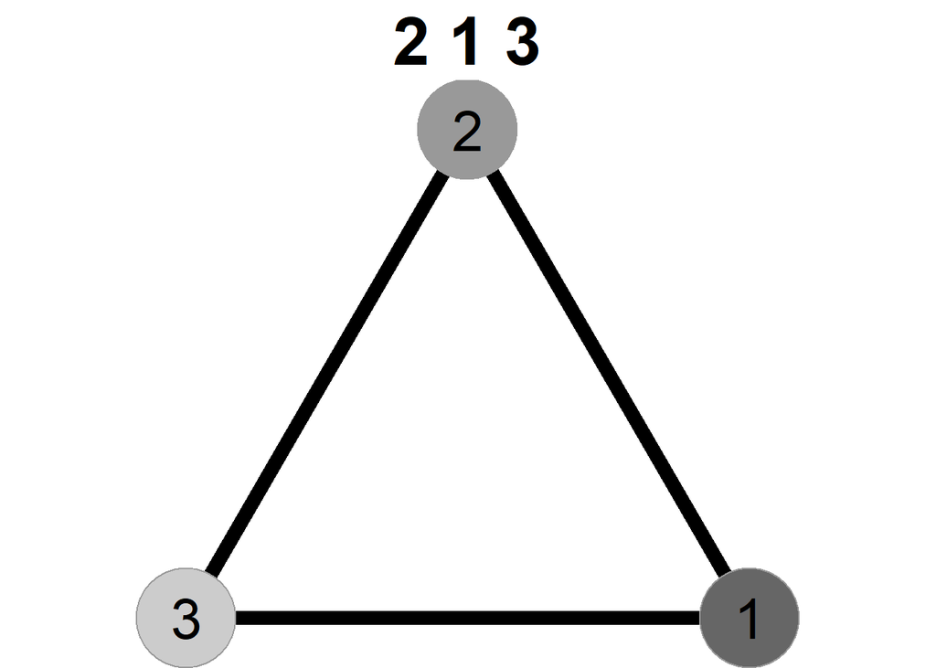

$S_D$

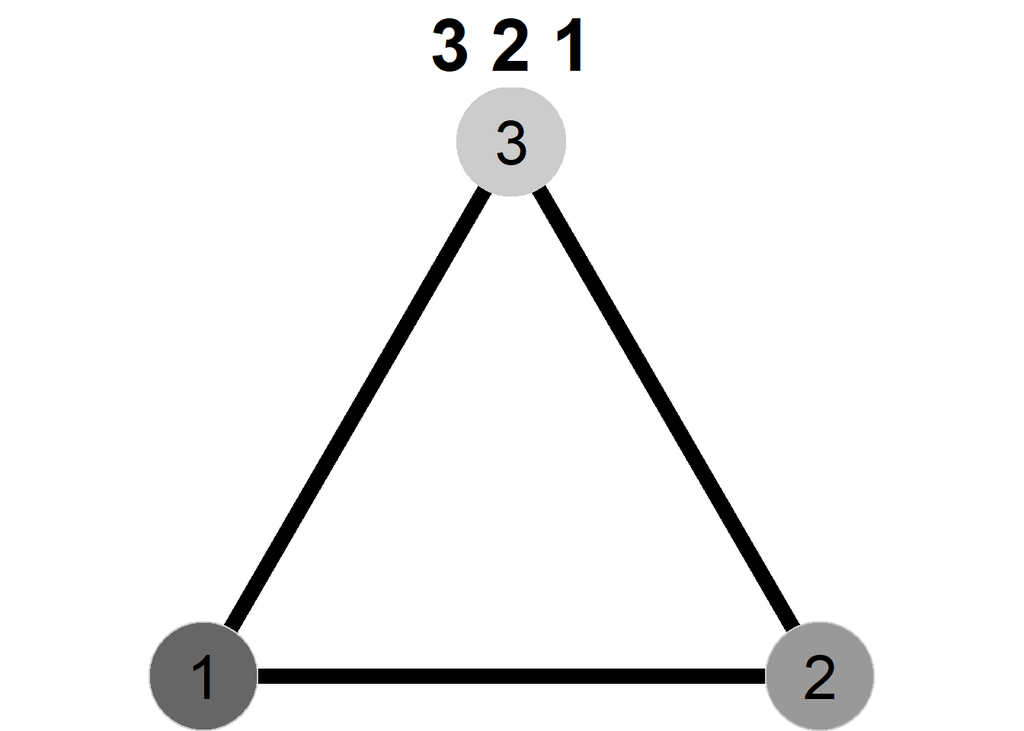

$S_L$

```r
# Fig. /*!\hyperref[fig:D3]{\ref{fig:D3}}!*/  symmetries in /*!$D_3$!*/
R> for(i in seq_len(nrow(pmd))) {
# cluster vector from a single combination
+    clu <- as.vector(unlist(pmd[i,]))
# permuted matrix and title according to 'clu'
+    ptri <- perm(tri, clu=clu)
+    titl <- jnt(clu, sep=" ", unique=TRUE)
# vertex colour
+    colv <- gray(2:4/5)[as.vector(as.numeric(attr(ptri,"dimnames")[[1]]))]
# plot graph with the respective transformation
+    multigraph(ptri, scope=scpt, vcol=colv, main=titl)
+    }
```

Rotations

Reflections

### Group structure of $D_3$

```r
# the generator relations
SD3 <- transf(list(R=c("2, 1", "3, 2", "1, 3"), S=c("1, 1", "3, 2", "2, 3")), type="toarray", sort=TRUE)
```

```
, , R

  1 2 3
1 0 0 1
2 1 0 0
3 0 1 0

, , S

  1 2 3
1 1 0 0
2 0 0 1
3 0 1 0
```

#### Producing the Cayley table

```r
# find the group structure of 'SD3'
SD3S <- semigroup(SD3)
```

For the rearrangement of `SD3S`, we find representative strings and the set of equations

```r
# representative strings
strings(SD3)$st
```

```
[1] "R"  "S"  "RR" "RS" "SR" "SS"
```

```r
# equations until length 3
strings(SD3, equat=TRUE, k=3)$equat
```

```
$R
[1] "R"   "SSR" "RSS"

$S
[1] "S"   "SSS" "RSR"

$RR
[1] "RR"  "SRS"

$RS
[1] "RS"  "SRR"

$SR
[1] "SR"  "RRS"

$SS
[1] "SS"  "RRR"
```

Then `SD3S` becomes the rearrangement of the multiplication table where the identity comes first, and then the generator relations.

```r
# permutation of multiplication table
SD3S <- perm(SD3S$S, clu=c(2, 4, 3, 5, 6, 1))
```

```
  6 1 3 2 4 5
6 6 1 3 2 4 5
1 1 3 6 4 5 2
3 3 6 1 5 2 4
2 2 5 4 6 3 1
4 4 2 5 1 6 3
5 5 4 2 3 1 6
```

And then we proceed with customized relabel `SD3S` in a (semi)group structure with generators

```r
# semigroup object with customized labels
SD3S <- as.semigroup(SD3S, gens=c(2, 4), lbs=c("R0", "R120", "R240", "SV", "SD", "SL"))
```

```
$ord
[1] 6

$st
[1] "R0"   "R120" "R240" "SV"   "SD"   "SL"

$gens
[1] "R120" "SV"

$S
       R0 R120 R240   SV   SD   SL
R0     R0 R120 R240   SV   SD   SL
R120 R120 R240   R0   SD   SL   SV
R240 R240   R0 R120   SL   SV   SD
SV     SV   SL   SD   R0 R240 R120
SD     SD   SV   SL R120   R0 R240
SL     SL   SD   SV R240 R120   R0

attr(,"class")
[1] "Semigroup" "symbolic"
```

#### Cayley graph

The Cayley graph of $D_3$ has another scope.

```r
# define scope of node / edge characteristics
scp0 <- list(cex=7, lty=1, lwd=3, pos=0, vcol=8, fsize=16)
```

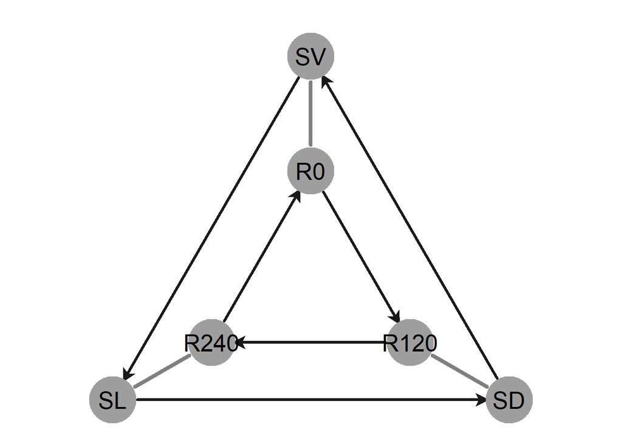

Cayley graph of $D_3$

```r
# reciprocal ties as undirected edges
ccgraph101(SD3S, conc=TRUE, nr=2, scope=scp0, undRecip=TRUE)
```

## Dihedral group of the Square

For the Dihedral group of the Square, denoted as $D_4$,

Form square…

```r
# matrix construct for the square
sqr <- transf(c("a, b", "b, c", "c, d", "d, a"))
```

```r
# define scope of node / edge / graph characteristics
scps <- list(directed=FALSE, cex=16, vcol=gray(2:5/6), clu=1:4, lwd=8,
+    ecol=1, pos=0, fsize=60)
```

### Plotting

Transformations are plotted

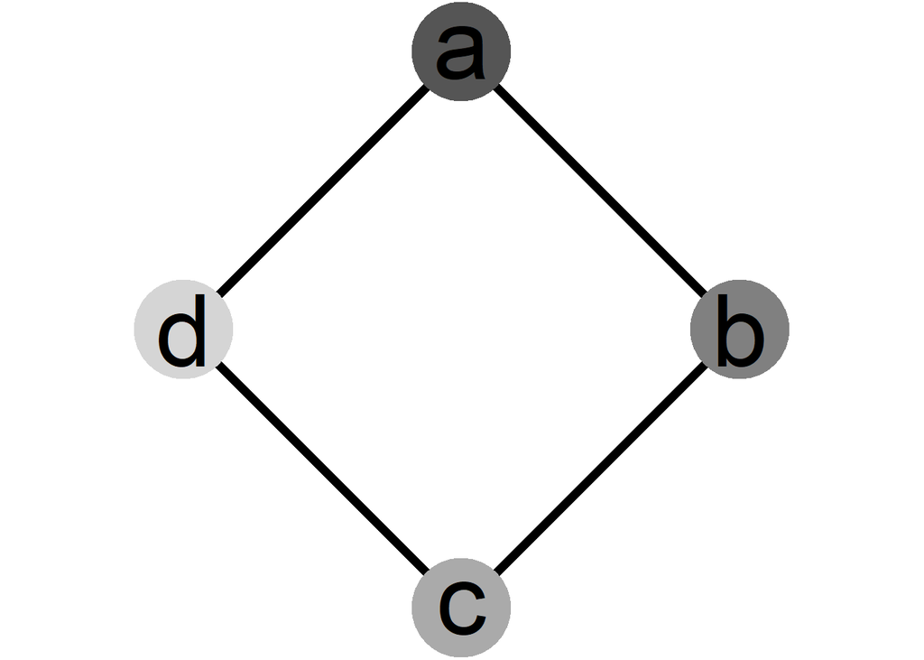

$R_{0}$

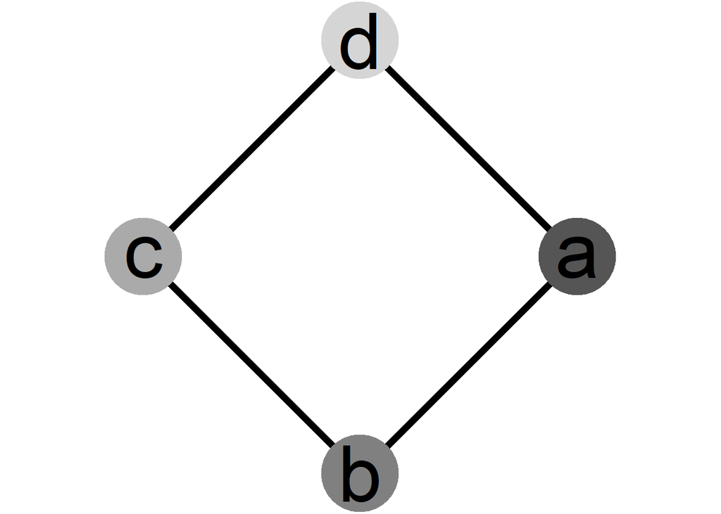

$R_{90}$

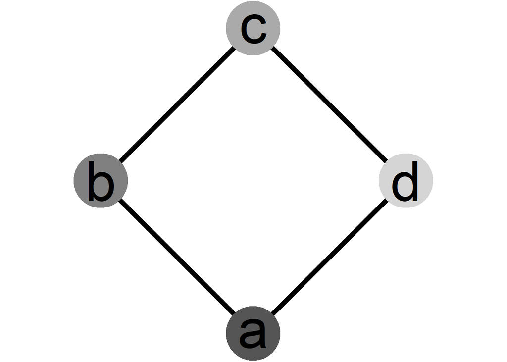

$R_{180}$

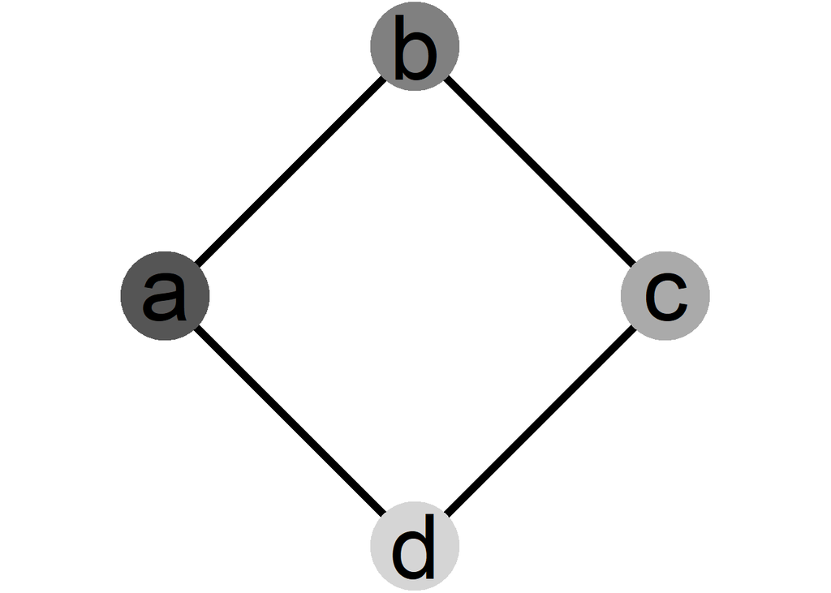

$R_{270}$

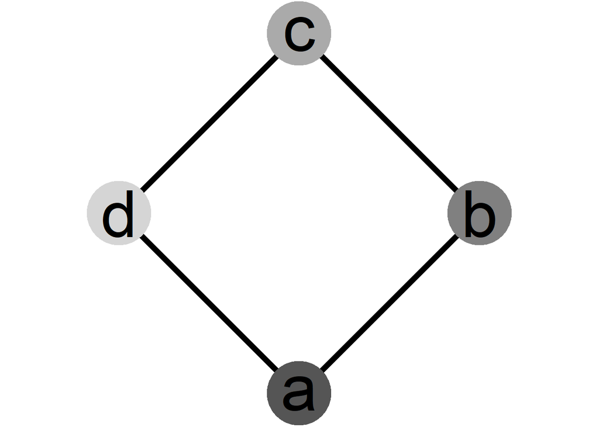

$S_H$

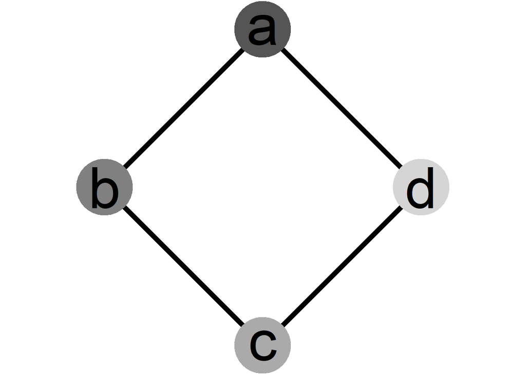

$S_V$

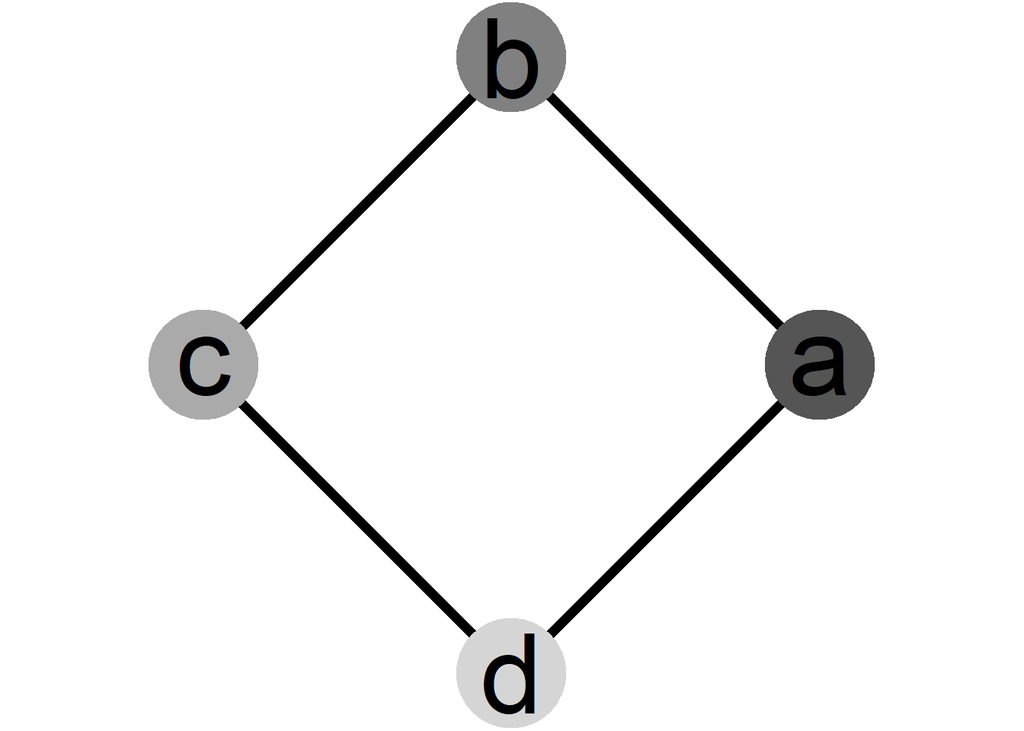

$S_D$

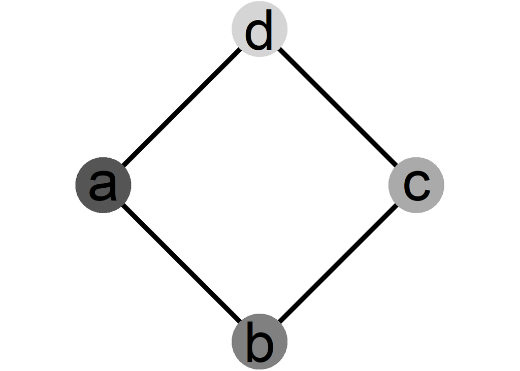

$S_L$

```r
## Fig. /*!\hyperref[fig:D4]{\ref{fig:D4}}!*/  elements in /*!$D_4$!*/
# Identity (no action)
R> multigraph(sqr, scope=scps)
# Rotation clockwise 90 degrees about the center
R> multigraph(sqr, scope=scps, rot=90)
# Rotation clockwise 180 degrees about the center
R> multigraph(sqr, scope=scps, rot=180)
# Rotation clockwise 270 degrees about the center
R> multigraph(sqr, scope=scps, rot=270)
# Reflection through the horizontal center line
R> multigraph(sqr, scope=scps, mirrorH=TRUE)
# Reflection through the vertical center line
R> multigraph(sqr, scope=scps, mirrorV=TRUE)
# Reflection across diagonal Y=X
R> multigraph(sqr, scope=scps, mirrorD=TRUE)
# Reflection across diagonal Y=-X
R> multigraph(sqr, scope=scps, mirrorL=TRUE)
```

### Group structure of $D_4$

```r
# the generator relations
SD4 <- transf(list(R=c("2, 1", "3, 2", "4, 3", "1, 4"),
+    S=c("1, 3", "2, 2", "3, 1", "4, 4")), type="toarray", sort=TRUE)
```

```
, , R

  1 2 3 4
1 0 0 0 1
2 1 0 0 0
3 0 1 0 0
4 0 0 1 0

, , S

  1 2 3 4
1 0 0 1 0
2 0 1 0 0
3 1 0 0 0
4 0 0 0 1
```

Group of `SD4` as a semigroup class object.

```r
# symbolic format
SD4S <- semigroup(SD4, type="symbolic")
```

#### Cayley table

Similarly, the rearrangement of semigroup in `SD4S` is identity first, then cycle (sub)group $R^3$.

```r
# permutation function
SD4S <- perm(SD4S$S, clu=c(2, 5, 3, 6, 8, 1, 4, 7))
```

```
     SS   R  RR RRR   S  RS RRS  SR
SS   SS   R  RR RRR   S  RS RRS  SR
R     R  RR RRR  SS  RS RRS  SR   S
RR   RR RRR  SS   R RRS  SR   S  RS
RRR RRR  SS   R  RR  SR   S  RS RRS
S     S  SR RRS  RS  SS RRR  RR   R
RS   RS   S  SR RRS   R  SS RRR  RR
RRS RRS  RS   S  SR  RR   R  SS RRR
SR   SR RRS  RS   S RRR  RR   R  SS
```

Then comes the relabeling of representative strings.

```r
# relabel 'SD4S'
SD4S <- as.semigroup(SD4S, gens=c(2, 5), lbs=c("R0", "R90", "R180", "R270", "SH", "SL", "SV", "SD"))
SD4S
```

```
$ord
[1] 8

$st
[1] "R0"   "R90"  "R180" "R270" "SH"   "SL"   "SV"   "SD"

$gens
[1] "R90" "SH"

$S
       R0  R90 R180 R270   SH   SL   SV   SD
R0     R0  R90 R180 R270   SH   SL   SV   SD
R90   R90 R180 R270   R0   SL   SV   SD   SH
R180 R180 R270   R0  R90   SV   SD   SH   SL
R270 R270   R0  R90 R180   SD   SH   SL   SV
SH     SH   SD   SV   SL   R0 R270 R180  R90
SL     SL   SH   SD   SV  R90   R0 R270 R180
SV     SV   SL   SH   SD R180  R90   R0 R270
SD     SD   SV   SL   SH R270 R180  R90   R0

attr(,"class")
[1] "Semigroup" "symbolic"
```

#### Cayley graph

The Cayley graph of $D_4$ has the same scope as $D_3$, and it is also with s concentric layout.

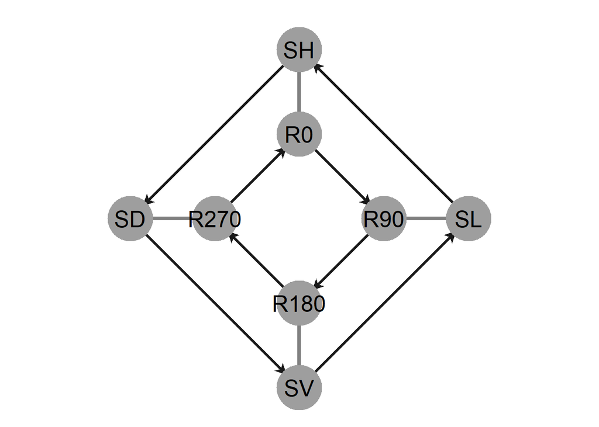

Cayley graph of $D_4$

```r
# reciprocals are undirected
ccgraph101(SD4S, conc=TRUE, nr=2, scope=scp0, undRecip=TRUE)
```

## Kariera kinship network

We start by constructing two permutation matrices for marriage and descent rules of the Kariera society.

```r
# transform pairwise list of lists into array
R> kks <- transf(list(F=c("1, 2", "3, 4", "2, 1", "4, 3"),
+    G=c("1, 4", "2, 3", "3, 2", "4, 1")), type="toarray")
```

```
, , F

  1 2 3 4
1 0 1 0 0
2 1 0 0 0
3 0 0 0 1
4 0 0 1 0

, , G

  1 2 3 4
1 0 0 0 1
2 0 0 1 0
3 0 1 0 0
4 1 0 0 0
```

### Graph representation of the Kariera society

```r
# define scope of node / edge / graph characteristics
scpKS <- list(cex=10, lwd=5, pos=0, vcol=8, ecol=1, collRecip=TRUE)
```

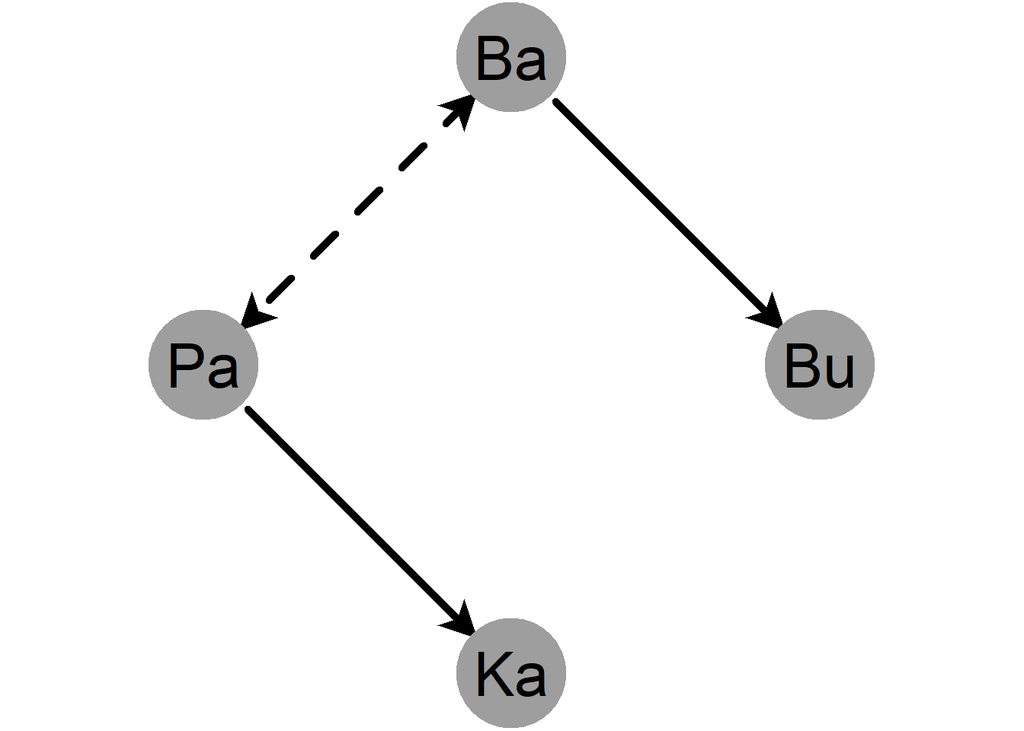

*Kariera 1*

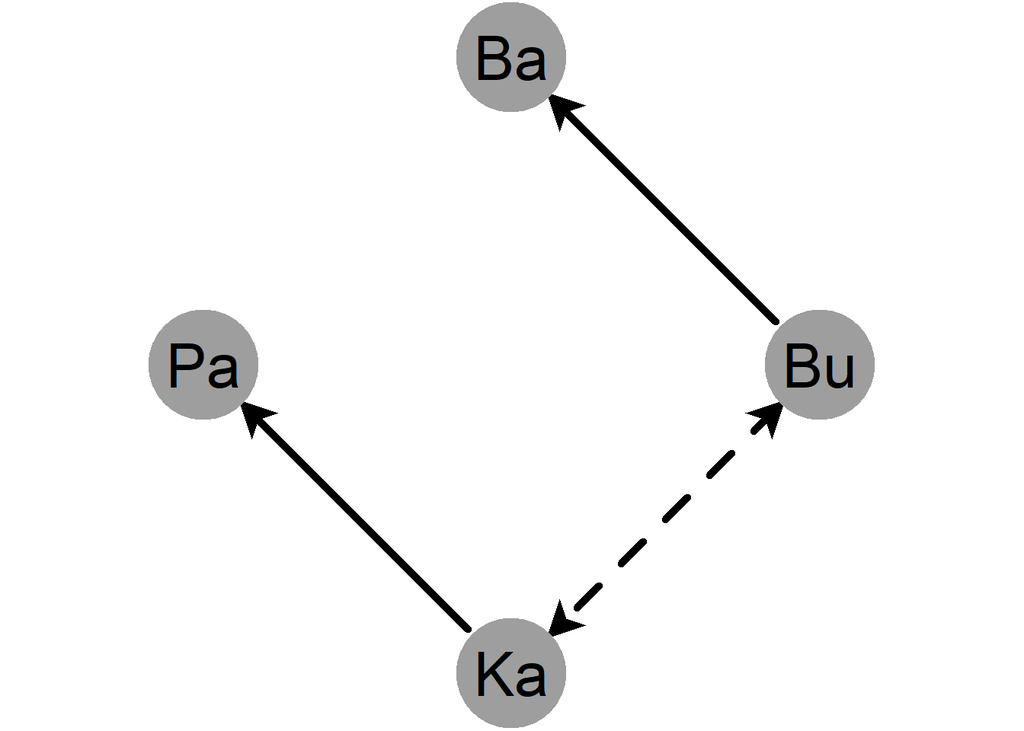

*Kariera 2*

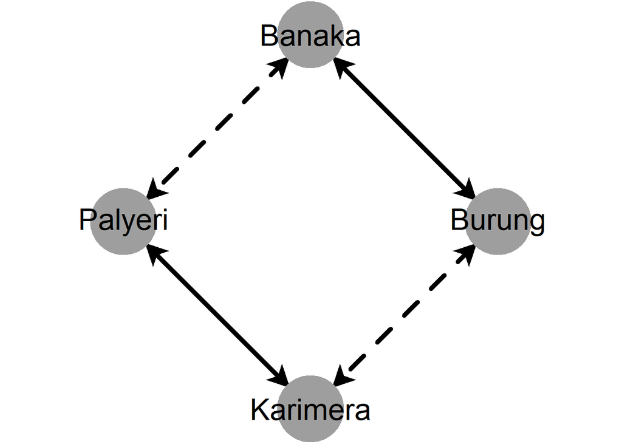

*Kariera 3*

```r
# Kariera 1
R> multigraph(transf(list(M=c("Ba, Bu", "Pa, Ka"), D=c("Ba, Pa", "Pa, Ba")),
+    lbs=c("Ba","Bu","Ka","Pa")), scope=scpKS)
# Kariera 2
R> multigraph(transf(list(M=c("Bu, Ba", "Ka, Pa"), D=c("Bu, Ka", "Ka, Bu")),
+    lbs=c("Ba","Bu","Ka","Pa")), scope=scpKS)
# Kariera 3
R> multigraph(kks, lbs=c("Banaka", "Burung", "Karimera", "Palyeri"),
+    scope=scpKS, fsize=20)
```

### Relational structure of the Kariera

##### Content

- Introduction – Monastery novices network
- Elementary Algebraic Structures
- Role Structure in Multiplex Networks
- Decomposition of Role Structures
- Signed Networks
- Affiliation Networks
- Multilevel Networks